# Simulation modeling to inform COVID-19 control and vaccination strategies

2020-11-04 13:11:44

## Introduction

- SARS-CoV-2/COVID-19 continues to remain a major concern.
- Non-pharmaceutical interventions (NPI) are currently the main method of control.
- Hopefully soon vaccines will be available and help to reduce the future impact of COVID.
- **Simulation modeling** can be a useful tool to make forecasts and evaluate the impact of different interventions.

## Simulation modeling areas

[figure not shown]

Source: NOAA

- Weather forecasting.
- Simulations of man-made, engineered system.
- Predicting the economy.
- **Infectious disease transmission.**

## Simulation modeling overview

- Build a model that simulates the process of disease transmission.
- Include any details that are relevant for the question, omit everything else.

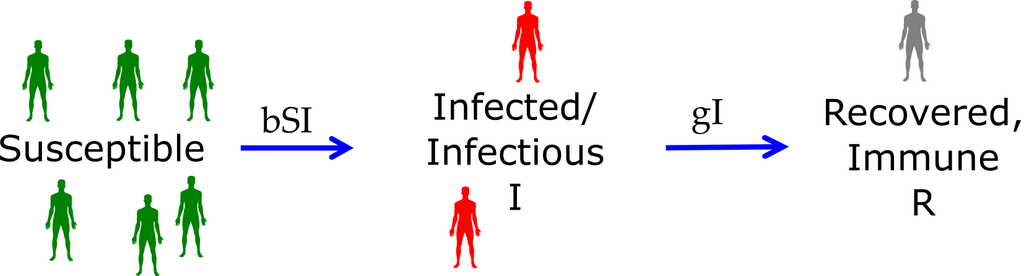

## Simulation modeling uses - Understanding

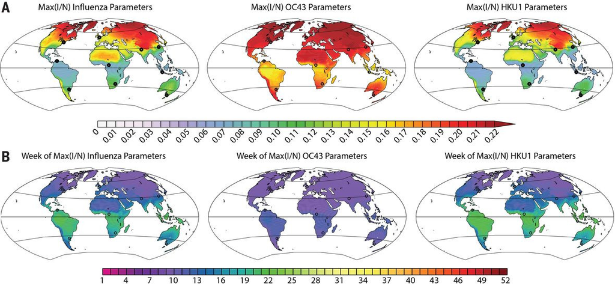

Baker et al. https://doi.org/10.1126/science.abc2535

## Simulation modeling uses - Forecasting

[figure not shown]

https://covid19forecasthub.org/

## Simulation modeling uses - Intervention Assessment

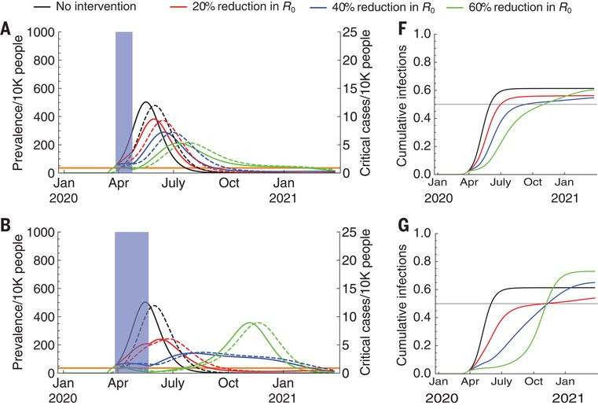

Kissler et al. https://doi.org/10.1126/science.abb5793

## A few of my recent COVID modeling projects

## Forecasting COVID in the US

## Motivation

- We wanted to know how many cases/hospitalizations/deaths to expect.
- We were initially asked by the state of Georgia’s governor office.
- We then extended it to all US states.

## Model

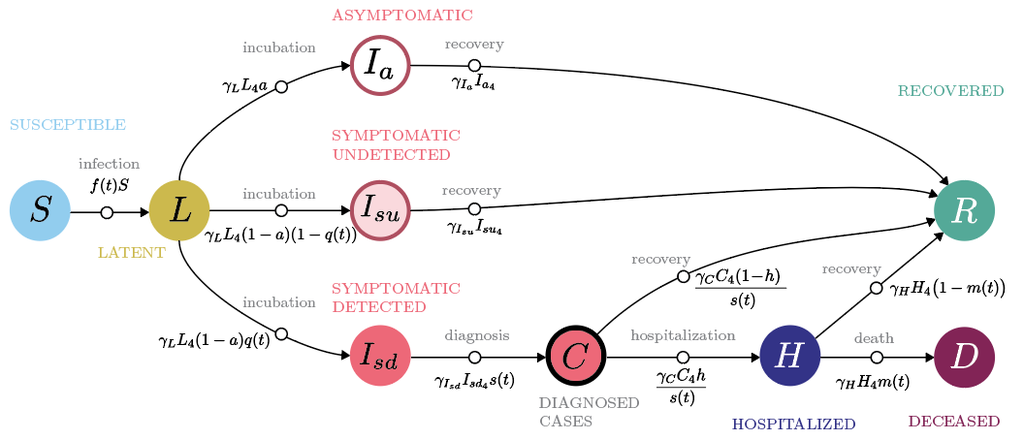

- Model is fit to case and death data for each state, then used to forecast.

## Results (state of GA)

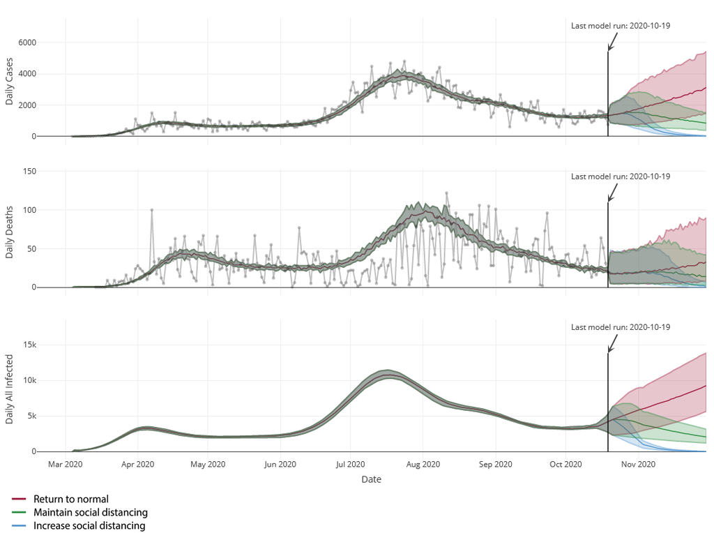

## Acknowledgments and More Information

- Collaborators: John Drake, Andrew Tredennick, Eamon O’Dea, Tierney O’Sullivan, Eric Marty
- More information: https://www.covid19.uga.edu/forecast.html

## Disease surveillance and screening to control COVID on university campuses

## Motivation

- We wanted to know if/how one could safely re-open college campuses.
- Emory University approached my colleague Ben Lopman. We built a somewhat general model.

## Methods

- Simulation model for COVID-19 spread and screening/testing based control.

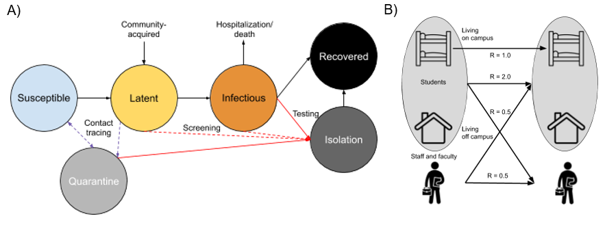

## Results

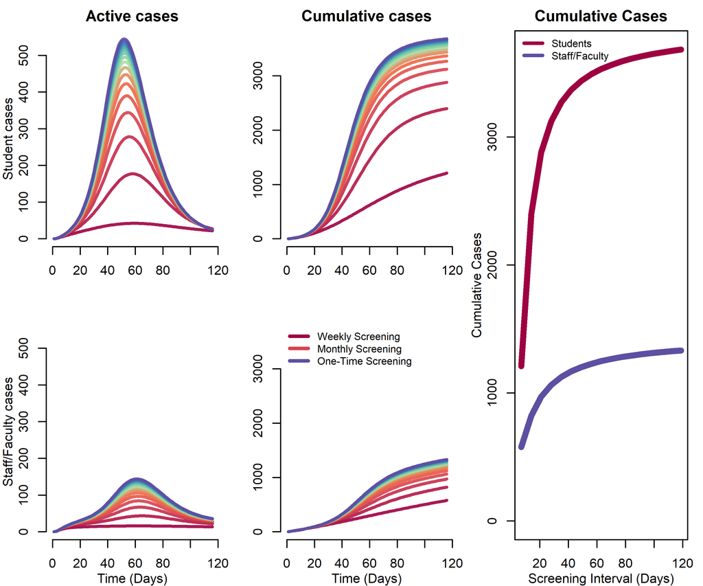

## Acknowledgments and More Information

- Collaborators: Ben Lopman, Carol Y. Liu, Adrien Le Guillou, Timothy L. Lash, Alexander P. Isakov, Samuel M. Jenness.
- Pre-print: https://www.medrxiv.org/content/10.1101/2020.06.23.20138677v3
- Online app: https://epimodel.shinyapps.io/covid-university/

## Modeling the impact of non-pharmaceutical interventions to suppress COVID spread

## Motivation

- We wanted to assess the impact of different non-pharmaceutical interventions (NPI) on controlling COVID in Zhejiang Province, China.
- We wanted to determine the impact of NPI on future cases.

## Model and fit to data

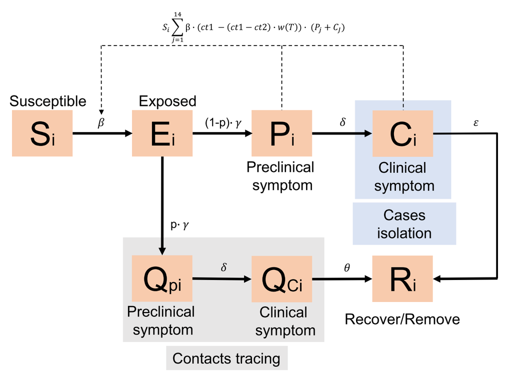

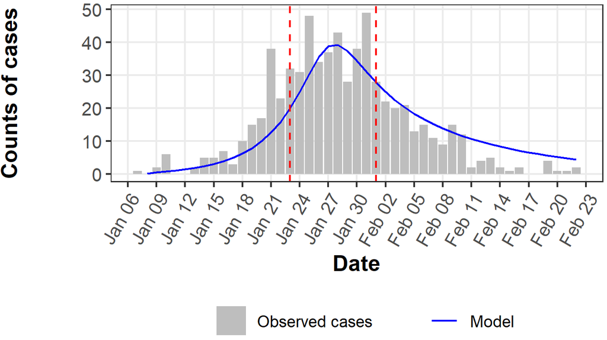

## Results

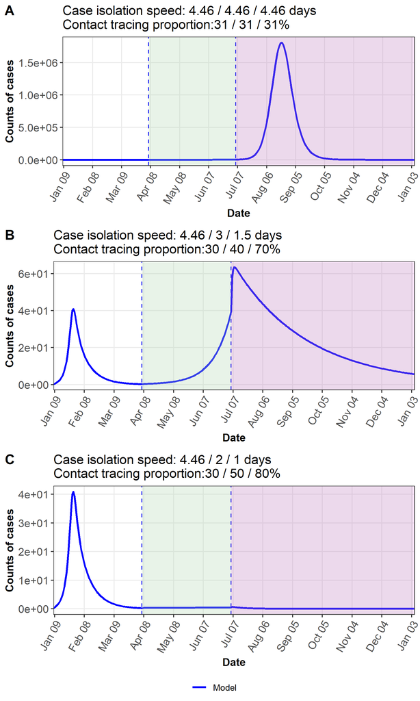

## Acknowledgments and More Information

- Collaborators: Yang Ge, Zhiping Chen, Leonardo Martinez, Qian Xiao, Changwei Li, Enfu Chen, Jinren Pan, Yang Li, Feng Ling, Ye Shen
- More information: prepared for submission

## Evaluating the impact of future COVID vaccines

## Motivation

- As COVID vaccines become (hopefully soon) available, figuring out how to roll them out in the most efficient way is not easy.
- We can build simulation models that include vaccination, explore the impact of different vaccination strategies for currently hypothetical, later real vaccine candidates.

## Model

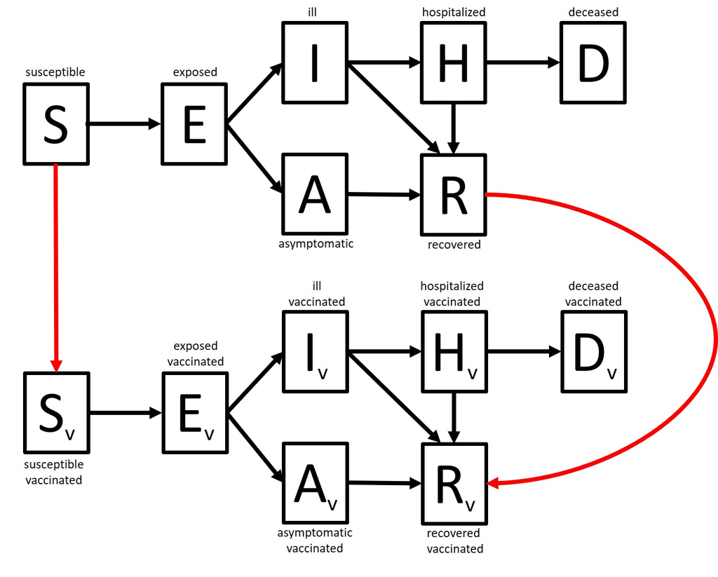

## Results

[figure not shown]

## Acknowledgments and More Information

- Collaborators: Molly E. Gallagher, Andrew J. Sieben, Kristin N. Nelson, Alicia N. M. Kraay, Ben Lopman, Katia Koelle
- More information: https://www.medrxiv.org/content/10.1101/2020.08.07.20170456v1

## Summary

- Collaborators: Many, see previous slides
- Funding: NIH
- Slides: https://www.andreashandel.com/talk/
- Web: https://www.andreashandel.com/
- Twitter: @andreashandel
- Email: ahandel@uga.edu